# Capstone Project - The Battle of Neighborhoods

Stuart McGill

### 1. Introduction

#### 1.1 Business Problem: Searching for a New home in a New City

According to the [US Census Bureau](https://www.census.gov/data/tables/time-series/demo/geographic-mobility/historic.html), every year approximately 32 Million Americans move home. Moving to a new city is a difficult undertaking and can result in a lot of stress. Especially when you like the facilities and venues in your current accommodation. There may be many different locations in a vast number of neighbourhoods to choose from.

Albert Einstein famously worked on three rules, [“Out of clutter, find simplicity. From discord, find harmony. In the middle of difficulty, lies opportunity.”](http://www.bigear.org/vol1no4/wheeler.htm). The difficulty faced by the huge number of people moving home annually and real-estate and rental industries make up the target audience of stakeholders who face this problem. Simplifying the search for new accommodation in a new city has real value for people moving home by reducing the cognitive load and accompanying stress. Having a way to contextualise real-estate / rental listings based on a users current location would give a real-estate company a competitive advantage. These reasons explain why people moving to a new city and real-estate / rental-listing companies care about simplifying the problem of search for a new home in an new city.

#### 1.2 Solution: Contextualize the Unfamiliar City

To make moving home easier, you need a reference point, where potential neighborhoods in the new city are compared to your current location. Imagine a real-estate / rental-listing website (such as [zillow](https://www.zillow.com/) or [realtor](https://www.realtor.com/) being able to contextualise the potential neighborhoods based on their similarity of surrounding facilities to your current accommodation. To do this, the user’s current city’s neighbourhoods would be clustered. These clusters would then be used as class labels, for training a classification algorithm. This classifier would then assign neighborhoods in the new city to be like neighbourhood clusters in the current city. This would provide the user with a common reference point to filter their options, reducing the cognitive demand of selecting a new home.

As a proof of concept case study, Los Angeles (USA) is selected as the current city and New York City (USA) is selected as the moving location. Then a three-step process is applied with the aim to make unfamiliar New York understandable by relating the neighborhoods to Los Angeles:

1. The neighborhoods of Los Angeles will be clustered based on their surrounding facilities.
2. These clusters will be used as labels to train a classifier.
3. The classifier will then be applied to New York City neighborhoods, providing context for the new city via analogy to the current residence.

### 2. Data

#### 2.1 Sources

Neighborhood names and boundaries, as defined by the latitude, longitude coordinates of bounding polygons of the will be sourced from [Neighborhood Data for Social Change](https://usc.data.socrata.com/dataset/Los-Angeles-Neighborhood-Map/r8qd-yxsr) for Los Angeles and [New York Open Data](https://data.cityofnewyork.us/City-Government/Neighborhood-Tabulation-Areas-NTA-/cpf4-rkhq) for New York City. To simplify what venues are considered to be within a neighbourhood, the [centroid of the bounding polygon](https://en.wikipedia.org/wiki/Centroid#Of_a_polygon) will be calculated. Venues will be considered as part of the neighbourhood if they fall within 1000 metre radius of the centroid of each neighborhood polygon (see data exploration for update).

The types of venues (categories) of the surrounding businesses and facilities in each neighbourhood will be sourced from the [Foursquare Places API](https://developer.foursquare.com/docs/api). The venue categories might not be distinct, for example cafes, coffee houses, and coffee bars should probably be considered the same type of venue. So the venue categories will be clustered based on their semantic meaning using a natural-language-processing word-embedding distance metric.

Each category cluster will form a feature dimension for clustering and classification. For each neighborhood, the number of venues in each category cluster will be counted. Then each category cluster count will be divided by the total neighborhood venues. So, the features of each neighborhood are the venue category clusters as a proportion of the total venues within the neighborhood.

The neighborhood proportion-venue vector, that sums to one, can be considered to fall with in a [simplex](https://en.wikipedia.org/wiki/Simplex). A simplex can be considered to be a generalization of the idea of a triangle to any number of dimensions. The neighborhood features fall within the space defined by the simplex. This complicates comparing neighborhoods because their feature vectors are not well described by Euclidean metrics as their space is non-Euclidean. Therefore, the [Hilbert simplex distance](https://arxiv.org/pdf/1704.00454.pdf) will be used as an appropriate distance metric for this data.

#### 2.2 Getting the data

The follwing maps demonstrate that the neighborhoods in each city are quite different. Los Angeles has much larger neighborhood areas compared to New York City, and has a quite a few very large neighborhoods. This is an important factor to consider when gathering the neighborhood facilities. Originally, it was planned to use a venue inclusion radius of 1000 metres for both cities. However,Given the difference in areas, the venue inclusion radius for Los Angeles is set to 1250 metres, whereas the inclusion radius for New York City is set to 500 metres. These values were determined with a boxplot of the neighborhood areas in each city as shown in figure 1.

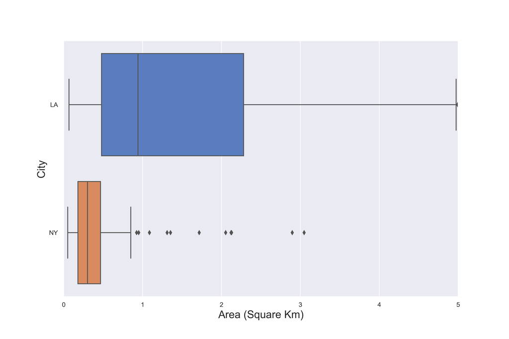

figure 1: Neighborhood Areas by City

##### Map of Los Angeles Neighborhoods

[interactive chart not shown]

##### Map of New York City Neighborhoods

[interactive chart not shown]

Given the neighborhood radius definitions, outlier Los Angeles neighborhoods were excluded from further analysis. The map below shows the excluded neighborhoods highlighted in red with centroids placed within each neighborhood.

##### Map of Los Angeles Neighborhood Centroids (outliers excluded)

[interactive chart not shown]

##### Map of New York City Neighborhood Centroids (outliers excluded)

[interactive chart not shown]

### 3. Methodology

#### 3.1 Feature Exploration and Engineering: Clustering Venue Categories via Natural Language Processing

The venue categories for all the surrounding venues, at each neighborhood in Los Angeles and New York City form the features for the clustering and classification. However, there is no guarentee that the categories are mutually exclusive. So exploration of their sematic similarity is needed to assess whether some categories need to be combined.

This presents its own challenge as there are over 400 categories to compare. In order to make this comparison more managable, venue categories were converted into 100 dimensional vectors using the *word2vec* embedding trained on wikipedia data (available [here](http://wikipedia2vec.s3.amazonaws.com/models/en/2018-04-20/enwiki_20180420_100d.txt.bz2)).

The venue categories were converted by first splitting them into lists of single words, then each word was converted to the vector. The vectors were summed together then divided by the total number of words in the category. This produced one 100 dimesion vector per category (venue vector).

The venue vectors distance matrix was calculated using the cosine distance metric. Subsequently the vectors were clustered with Agglomerative Heirarchical Clustering and visualised with a dendrogram. The threshold of .1 was chosed, by visual inspection, below which all venues were manually inspected for semantic overlap. 55 categories were found to have some degree of overlap and were combined into 24 categories.

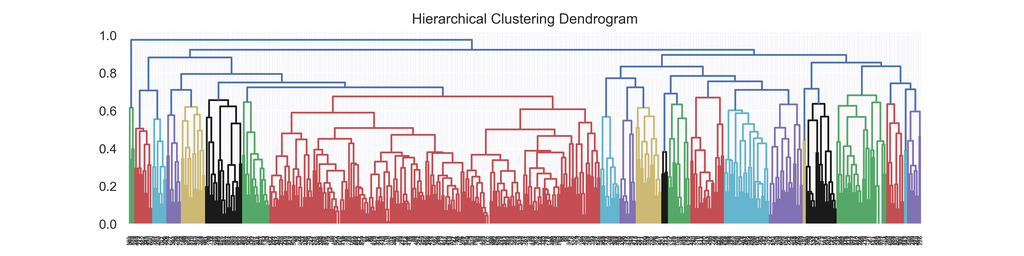

figure 2: Venue Category Dendrogram

After combination there were 464 venue categories. These were one-hot-encoded and summed together for each neighborhood. This formed a multinomial vector representing each neighborhood. These neighborhood vectors were converted into simplexes (vectors whos elements sum to one) using Dirichlet flat prior (adding one to each element then dividing by the vector by the sum of each row). This meant that each simplex represented an estimate of the proportion of venue categories surrounding each neighborhood.